# (Ford gobike Data Analysis)

## Preliminary Wrangling

> Ford GoBike is bike share system consists of a fleet of bikes that can be unlocked in one station and returned in any other network station, Thus, this is ideal for one-way trips, These bikes are available for use thorughout the year and riders have access to all bikes in the network.

```python
# import all packages and set plots to be embedded inline
import numpy as np
import pandas as pd
import matplotlib.pyplot as plt
import seaborn as sb
from datetime import date
import math

pd.set_option('display.max_columns', None)
pd.set_option('display.max_rows', None)
base_color = sb.color_palette()[0]


%matplotlib inline
```

> Load in your dataset and describe its properties through the questions below. Try and motivate your exploration goals through this section.

```python
#Load and make a copy from the data set
fordgobike_df = pd.read_csv('201902-fordgobike-tripdata.csv')
df = fordgobike_df.copy()
```

#### Explore the data set

```python
df.shape
```

```
(183412, 16)
```

```python
df.info()
```

```
<class 'pandas.core.frame.DataFrame'>
RangeIndex: 183412 entries, 0 to 183411
Data columns (total 16 columns):
 #   Column                   Non-Null Count   Dtype
---  ------                   --------------   -----
 0   duration_sec             183412 non-null  int64
 1   start_time               183412 non-null  object
 2   end_time                 183412 non-null  object
 3   start_station_id         183215 non-null  float64
 4   start_station_name       183215 non-null  object
 5   start_station_latitude   183412 non-null  float64
 6   start_station_longitude  183412 non-null  float64
 7   end_station_id           183215 non-null  float64
 8   end_station_name         183215 non-null  object
 9   end_station_latitude     183412 non-null  float64
 10  end_station_longitude    183412 non-null  float64
 11  bike_id                  183412 non-null  int64
 12  user_type                183412 non-null  object
 13  member_birth_year        175147 non-null  float64
 14  member_gender            175147 non-null  object
 15  bike_share_for_all_trip  183412 non-null  object
dtypes: float64(7), int64(2), object(7)
memory usage: 22.4+ MB
```

```python
df.duplicated().sum()
```

```
0
```

```python
df.nunique()
```

```
duration_sec                 4752
start_time                 183401
end_time                   183397
start_station_id              329
start_station_name            329
start_station_latitude        334
start_station_longitude       335
end_station_id                329
end_station_name              329
end_station_latitude          335
end_station_longitude         335
bike_id                      4646
user_type                       2
member_birth_year              75
member_gender                   3
bike_share_for_all_trip         2
dtype: int64
```

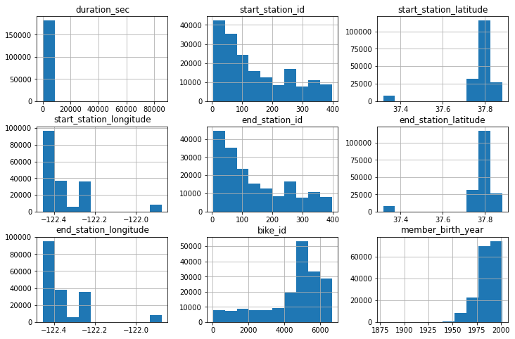

```python
df.hist(figsize=(12,8));
```

```python
df.isna().sum()
```

```
duration_sec                  0
start_time                    0
end_time                      0
start_station_id            197
start_station_name          197
start_station_latitude        0
start_station_longitude       0
end_station_id              197
end_station_name            197
end_station_latitude          0
end_station_longitude         0
bike_id                       0
user_type                     0
member_birth_year          8265
member_gender              8265
bike_share_for_all_trip       0
dtype: int64
```

```python
df.isnull().sum()
```

```
duration_sec                  0
start_time                    0
end_time                      0
start_station_id            197
start_station_name          197
start_station_latitude        0
start_station_longitude       0
end_station_id              197
end_station_name            197
end_station_latitude          0
end_station_longitude         0
bike_id                       0
user_type                     0
member_birth_year          8265
member_gender              8265
bike_share_for_all_trip       0
dtype: int64
```

#### Clean data set

```python
# Clean and drop null rows
df.drop(df[df.member_gender.isna() & df.member_birth_year.isna()].index, inplace=True)
df.member_gender.isna().sum()
```

```
0
```

```python
df.shape
```

```
(175147, 16)
```

```python
df.isna().sum()
```

```
duration_sec                 0
start_time                   0
end_time                     0
start_station_id           195
start_station_name         195
start_station_latitude       0
start_station_longitude      0
end_station_id             195
end_station_name           195
end_station_latitude         0
end_station_longitude        0
bike_id                      0
user_type                    0
member_birth_year            0
member_gender                0
bike_share_for_all_trip      0
dtype: int64
```

```python
# delete null rows and recheck data
df.drop(df[df.start_station_id.isnull()].index, inplace=True)
df.start_station_id.isna().sum()
df.start_station_latitude.isna().sum()
df.start_station_longitude.isna().sum()
df.start_station_name.isna().sum()
df.shape
```

```
(174952, 16)
```

```python
df.isnull().sum()
```

```
duration_sec               0
start_time                 0
end_time                   0
start_station_id           0
start_station_name         0
start_station_latitude     0
start_station_longitude    0
end_station_id             0
end_station_name           0
end_station_latitude       0
end_station_longitude      0
bike_id                    0
user_type                  0
member_birth_year          0
member_gender              0
bike_share_for_all_trip    0
dtype: int64
```

#### Wrangle and clean data set

```python
# Transform  columns to time type
df.start_time = pd.to_datetime(df.start_time)
df.end_time = pd.to_datetime(df.end_time)
df.info()
```

```
<class 'pandas.core.frame.DataFrame'>
Int64Index: 174952 entries, 0 to 183411
Data columns (total 16 columns):
 #   Column                   Non-Null Count   Dtype
---  ------                   --------------   -----
 0   duration_sec             174952 non-null  int64
 1   start_time               174952 non-null  datetime64[ns]
 2   end_time                 174952 non-null  datetime64[ns]
 3   start_station_id         174952 non-null  float64
 4   start_station_name       174952 non-null  object
 5   start_station_latitude   174952 non-null  float64
 6   start_station_longitude  174952 non-null  float64
 7   end_station_id           174952 non-null  float64
 8   end_station_name         174952 non-null  object
 9   end_station_latitude     174952 non-null  float64
 10  end_station_longitude    174952 non-null  float64
 11  bike_id                  174952 non-null  int64
 12  user_type                174952 non-null  object
 13  member_birth_year        174952 non-null  float64
 14  member_gender            174952 non-null  object
 15  bike_share_for_all_trip  174952 non-null  object
dtypes: datetime64[ns](2), float64(7), int64(2), object(5)
memory usage: 22.7+ MB
```

```python
# create a age new column
df['age'] = 2019 - df.member_birth_year
```

```python
#create new columns for analysis , create month column
df['month'] = df.start_time.dt.month_name()
```

```python
#create new columns for analysis , create day of the week column
df['day_of_week'] = df['start_time'].dt.strftime('%a')
```

```python
#create new columns for analysis , create start hr column
df['start_hr'] = df.start_time.dt.hour
```

```python
#create new columns for analysis , create duration in minutes column
df['duration_min'] = df.duration_sec / 60
```

```python
#create new columns for analysis , create duration in hours column
df['duration_hr'] = df.duration_min / 60
```

```python
df.head()
```

|  | duration_sec | start_time | end_time | start_station_id | start_station_name | start_station_latitude | start_station_longitude | end_station_id | end_station_name | end_station_latitude | end_station_longitude | bike_id | user_type | member_birth_year | member_gender | bike_share_for_all_trip | age | month | day_of_week | start_hr | duration_min | duration_hr |
| --- | --- | --- | --- | --- | --- | --- | --- | --- | --- | --- | --- | --- | --- | --- | --- | --- | --- | --- | --- | --- | --- | --- |
| 0 | 52185 | 2019-02-28 17:32:10.145 | 2019-03-01 08:01:55.975 | 21.0 | Montgomery St BART Station (Market St at 2nd St) | 37.789625 | -122.400811 | 13.0 | Commercial St at Montgomery St | 37.794231 | -122.402923 | 4902 | Customer | 1984.0 | Male | No | 35.0 | February | Thu | 17 | 869.750000 | 14.495833 |
| 2 | 61854 | 2019-02-28 12:13:13.218 | 2019-03-01 05:24:08.146 | 86.0 | Market St at Dolores St | 37.769305 | -122.426826 | 3.0 | Powell St BART Station (Market St at 4th St) | 37.786375 | -122.404904 | 5905 | Customer | 1972.0 | Male | No | 47.0 | February | Thu | 12 | 1030.900000 | 17.181667 |
| 3 | 36490 | 2019-02-28 17:54:26.010 | 2019-03-01 04:02:36.842 | 375.0 | Grove St at Masonic Ave | 37.774836 | -122.446546 | 70.0 | Central Ave at Fell St | 37.773311 | -122.444293 | 6638 | Subscriber | 1989.0 | Other | No | 30.0 | February | Thu | 17 | 608.166667 | 10.136111 |
| 4 | 1585 | 2019-02-28 23:54:18.549 | 2019-03-01 00:20:44.074 | 7.0 | Frank H Ogawa Plaza | 37.804562 | -122.271738 | 222.0 | 10th Ave at E 15th St | 37.792714 | -122.248780 | 4898 | Subscriber | 1974.0 | Male | Yes | 45.0 | February | Thu | 23 | 26.416667 | 0.440278 |
| 5 | 1793 | 2019-02-28 23:49:58.632 | 2019-03-01 00:19:51.760 | 93.0 | 4th St at Mission Bay Blvd S | 37.770407 | -122.391198 | 323.0 | Broadway at Kearny | 37.798014 | -122.405950 | 5200 | Subscriber | 1959.0 | Male | No | 60.0 | February | Thu | 23 | 29.883333 | 0.498056 |

```python
df.day_of_week.value_counts()
```

```
Thu    33712
Tue    30584
Wed    28426
Fri    27663
Mon    25641
Sun    14512
Sat    14414
Name: day_of_week, dtype: int64
```

```python
df.info()
```

```
<class 'pandas.core.frame.DataFrame'>
Int64Index: 174952 entries, 0 to 183411
Data columns (total 22 columns):
 #   Column                   Non-Null Count   Dtype
---  ------                   --------------   -----
 0   duration_sec             174952 non-null  int64
 1   start_time               174952 non-null  datetime64[ns]
 2   end_time                 174952 non-null  datetime64[ns]
 3   start_station_id         174952 non-null  float64
 4   start_station_name       174952 non-null  object
 5   start_station_latitude   174952 non-null  float64
 6   start_station_longitude  174952 non-null  float64
 7   end_station_id           174952 non-null  float64
 8   end_station_name         174952 non-null  object
 9   end_station_latitude     174952 non-null  float64
 10  end_station_longitude    174952 non-null  float64
 11  bike_id                  174952 non-null  int64
 12  user_type                174952 non-null  object
 13  member_birth_year        174952 non-null  float64
 14  member_gender            174952 non-null  object
 15  bike_share_for_all_trip  174952 non-null  object
 16  age                      174952 non-null  float64
 17  month                    174952 non-null  object
 18  day_of_week              174952 non-null  object
 19  start_hr                 174952 non-null  int64
 20  duration_min             174952 non-null  float64
 21  duration_hr              174952 non-null  float64
dtypes: datetime64[ns](2), float64(10), int64(3), object(7)
memory usage: 30.7+ MB
```

```python
df.drop(df[df.start_station_latitude == df.end_station_latitude].index, axis=0, inplace=True) # clean and drop zero distance rows as it might be faulty
```

```python
df[(df.start_station_latitude == df.end_station_latitude) & (df.start_station_longitude == df.end_station_longitude)].count()
```

```
duration_sec               0
start_time                 0
end_time                   0
start_station_id           0
start_station_name         0
start_station_latitude     0
start_station_longitude    0
end_station_id             0
end_station_name           0
end_station_latitude       0
end_station_longitude      0
bike_id                    0
user_type                  0
member_birth_year          0
member_gender              0
bike_share_for_all_trip    0
age                        0
month                      0
day_of_week                0
start_hr                   0
duration_min               0
duration_hr                0
dtype: int64
```

```python
df.info()
```

```
<class 'pandas.core.frame.DataFrame'>
Int64Index: 171494 entries, 0 to 183411
Data columns (total 22 columns):
 #   Column                   Non-Null Count   Dtype
---  ------                   --------------   -----
 0   duration_sec             171494 non-null  int64
 1   start_time               171494 non-null  datetime64[ns]
 2   end_time                 171494 non-null  datetime64[ns]
 3   start_station_id         171494 non-null  float64
 4   start_station_name       171494 non-null  object
 5   start_station_latitude   171494 non-null  float64
 6   start_station_longitude  171494 non-null  float64
 7   end_station_id           171494 non-null  float64
 8   end_station_name         171494 non-null  object
 9   end_station_latitude     171494 non-null  float64
 10  end_station_longitude    171494 non-null  float64
 11  bike_id                  171494 non-null  int64
 12  user_type                171494 non-null  object
 13  member_birth_year        171494 non-null  float64
 14  member_gender            171494 non-null  object
 15  bike_share_for_all_trip  171494 non-null  object
 16  age                      171494 non-null  float64
 17  month                    171494 non-null  object
 18  day_of_week              171494 non-null  object
 19  start_hr                 171494 non-null  int64
 20  duration_min             171494 non-null  float64
 21  duration_hr              171494 non-null  float64
dtypes: datetime64[ns](2), float64(10), int64(3), object(7)
memory usage: 30.1+ MB
```

```python
df.age.describe()
```

```
count    171494.000000
mean         34.195278
std          10.084265
min          18.000000
25%          27.000000
50%          32.000000
75%          39.000000
max         141.000000
Name: age, dtype: float64
```

```python
df.age.quantile(0.99)
```

```
64.0
```

```python
# remvoing outliers
df.drop(df[df.age > 64].index, inplace=True)
```

```python
df.duration_min.describe()
```

```
count    169878.000000
mean         11.367953
std          25.647278
min           1.016667
25%           5.383333
50%           8.466667
75%          12.983333
max        1409.133333
Name: duration_min, dtype: float64
```

```python
df.columns
```

```
Index(['duration_sec', 'start_time', 'end_time', 'start_station_id',
       'start_station_name', 'start_station_latitude',
       'start_station_longitude', 'end_station_id', 'end_station_name',
       'end_station_latitude', 'end_station_longitude', 'bike_id', 'user_type',
       'member_birth_year', 'member_gender', 'bike_share_for_all_trip', 'age',
       'month', 'day_of_week', 'start_hr', 'duration_min', 'duration_hr'],
      dtype='object')
```

#### Create a new clean data frame with only needed columns

```python
#Create a new  needed columns only
df_clean = df[['duration_min', 'duration_hr', 'day_of_week', 'start_hr', 'start_station_id',
                         'end_station_id',  'member_gender', 'age', 'user_type',  'bike_share_for_all_trip'  ]]
```

```python
df_clean.head()
```

|  | duration_min | duration_hr | day_of_week | start_hr | start_station_id | end_station_id | member_gender | age | user_type | bike_share_for_all_trip |
| --- | --- | --- | --- | --- | --- | --- | --- | --- | --- | --- |
| 0 | 869.750000 | 14.495833 | Thu | 17 | 21.0 | 13.0 | Male | 35.0 | Customer | No |
| 2 | 1030.900000 | 17.181667 | Thu | 12 | 86.0 | 3.0 | Male | 47.0 | Customer | No |
| 3 | 608.166667 | 10.136111 | Thu | 17 | 375.0 | 70.0 | Other | 30.0 | Subscriber | No |
| 4 | 26.416667 | 0.440278 | Thu | 23 | 7.0 | 222.0 | Male | 45.0 | Subscriber | Yes |
| 5 | 29.883333 | 0.498056 | Thu | 23 | 93.0 | 323.0 | Male | 60.0 | Subscriber | No |

```python
df_clean.describe()
```

|  | duration_min | duration_hr | start_hr | start_station_id | end_station_id | age |
| --- | --- | --- | --- | --- | --- | --- |
| count | 169878.000000 | 169878.000000 | 169878.000000 | 169878.000000 | 169878.000000 | 169878.000000 |
| mean | 11.367953 | 0.189466 | 13.451406 | 138.454344 | 135.979915 | 33.832533 |
| std | 25.647278 | 0.427455 | 4.742993 | 111.312914 | 110.955923 | 9.348979 |
| min | 1.016667 | 0.016944 | 0.000000 | 3.000000 | 3.000000 | 18.000000 |
| 25% | 5.383333 | 0.089722 | 9.000000 | 47.000000 | 44.000000 | 27.000000 |
| 50% | 8.466667 | 0.141111 | 14.000000 | 104.000000 | 100.000000 | 32.000000 |
| 75% | 12.983333 | 0.216389 | 17.000000 | 239.000000 | 233.000000 | 39.000000 |
| max | 1409.133333 | 23.485556 | 23.000000 | 398.000000 | 398.000000 | 64.000000 |

```python
df_clean.duration_min.quantile(0.99)
```

```
46.10383333333351
```

```python
# Revmoe duration column outliers
df_clean.drop(df_clean[df_clean.duration_min > df_clean.duration_min.quantile(0.99)].index, axis=0, inplace=True)
```

```python
df_clean.duration_min.describe()
```

```
count    168179.000000
mean         10.012615
std           6.622920
min           1.016667
25%           5.366667
50%           8.400000
75%          12.800000
max          46.100000
Name: duration_min, dtype: float64
```

### What is the structure of your dataset?

> The data set have 183412 rows, 16 columns , have time columns, catogrical and numeric data.

### What is/are the main feature(s) of interest in your dataset?

> Gender , Week days, Trip duration, age.

### What features in the dataset do you think will help support your investigation into your feature(s) of interest?

> Gender column, duration time column, week days column and age column are most interinsting for me, as it will get me some insights .

## Univariate Exploration

> In this section, investigate distributions of individual variables. If you see unusual points or outliers, take a deeper look to clean things up and prepare yourself to look at relationships between variables.

```python
df.head()
```

|  | duration_sec | start_time | end_time | start_station_id | start_station_name | start_station_latitude | start_station_longitude | end_station_id | end_station_name | end_station_latitude | end_station_longitude | bike_id | user_type | member_birth_year | member_gender | bike_share_for_all_trip | age | month | day_of_week | start_hr | duration_min | duration_hr |
| --- | --- | --- | --- | --- | --- | --- | --- | --- | --- | --- | --- | --- | --- | --- | --- | --- | --- | --- | --- | --- | --- | --- |
| 0 | 52185 | 2019-02-28 17:32:10.145 | 2019-03-01 08:01:55.975 | 21.0 | Montgomery St BART Station (Market St at 2nd St) | 37.789625 | -122.400811 | 13.0 | Commercial St at Montgomery St | 37.794231 | -122.402923 | 4902 | Customer | 1984.0 | Male | No | 35.0 | February | Thu | 17 | 869.750000 | 14.495833 |
| 2 | 61854 | 2019-02-28 12:13:13.218 | 2019-03-01 05:24:08.146 | 86.0 | Market St at Dolores St | 37.769305 | -122.426826 | 3.0 | Powell St BART Station (Market St at 4th St) | 37.786375 | -122.404904 | 5905 | Customer | 1972.0 | Male | No | 47.0 | February | Thu | 12 | 1030.900000 | 17.181667 |
| 3 | 36490 | 2019-02-28 17:54:26.010 | 2019-03-01 04:02:36.842 | 375.0 | Grove St at Masonic Ave | 37.774836 | -122.446546 | 70.0 | Central Ave at Fell St | 37.773311 | -122.444293 | 6638 | Subscriber | 1989.0 | Other | No | 30.0 | February | Thu | 17 | 608.166667 | 10.136111 |
| 4 | 1585 | 2019-02-28 23:54:18.549 | 2019-03-01 00:20:44.074 | 7.0 | Frank H Ogawa Plaza | 37.804562 | -122.271738 | 222.0 | 10th Ave at E 15th St | 37.792714 | -122.248780 | 4898 | Subscriber | 1974.0 | Male | Yes | 45.0 | February | Thu | 23 | 26.416667 | 0.440278 |
| 5 | 1793 | 2019-02-28 23:49:58.632 | 2019-03-01 00:19:51.760 | 93.0 | 4th St at Mission Bay Blvd S | 37.770407 | -122.391198 | 323.0 | Broadway at Kearny | 37.798014 | -122.405950 | 5200 | Subscriber | 1959.0 | Male | No | 60.0 | February | Thu | 23 | 29.883333 | 0.498056 |

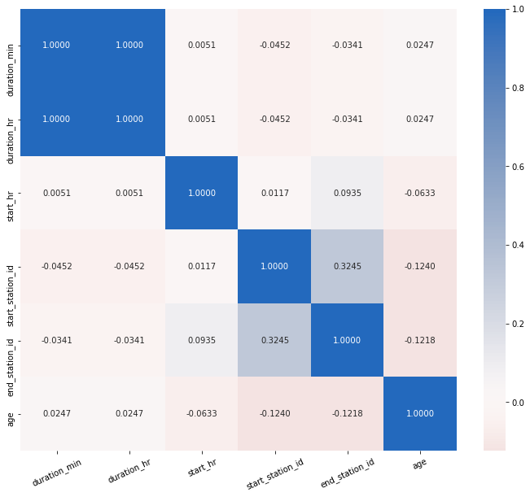

```python
# explore with correlation plot
plt.figure(figsize = [12, 10])
sb.heatmap(df_clean.corr() , annot = True, fmt = '.4f', cmap = 'vlag_r', center=0);
plt.xticks(rotation=25);
```

#### Checking correlation between variables

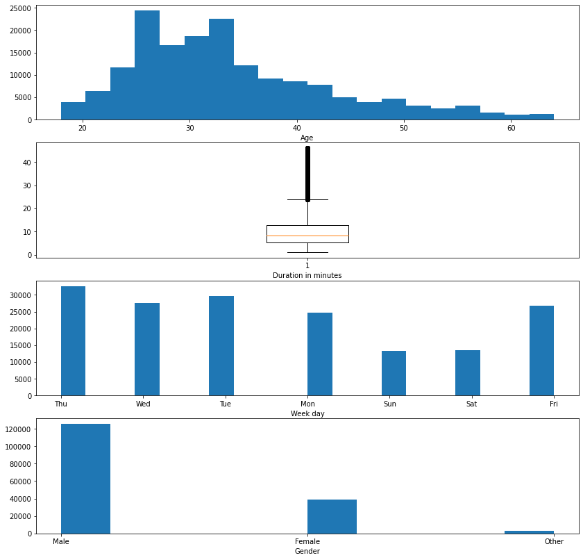

```python
# Explore more diffrent univariante columns
plt.figure(figsize = [14, 14])

# subplot 1: age
plt.subplot(4, 1, 1)
plt.hist(df_clean.age, bins=20)
plt.xlabel('Age')

# subplot 2: duration
plt.subplot(4, 1, 2)
plt.boxplot(df_clean.duration_min )
plt.xlabel('Duration in minutes');

# subplot 3: week day
plt.subplot(4, 1, 3)
plt.hist(df_clean.day_of_week, bins=20)
plt.xlabel('Week day')

# subplot 2: gender
plt.subplot(4, 1, 4)
plt.hist(df_clean.member_gender )
plt.xlabel('Gender');
```

#### > It seems that most of the users around age 30

#### > It seems that most common trip duration around 10 minutes

#### > It seems that users frequecy increase the most at thursday

#### > Most of the service users are men.

```python
df_clean.duration_min.describe()
```

```
count    168179.000000
mean         10.012615
std           6.622920
min           1.016667
25%           5.366667
50%           8.400000
75%          12.800000
max          46.100000
Name: duration_min, dtype: float64
```

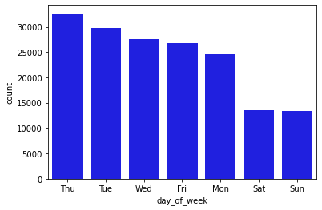

```python
sb.countplot(df_clean.day_of_week, order = df_clean.day_of_week.value_counts().index,  color='b');
```

#### Thursday is the most day for the service to be used

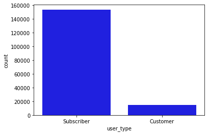

```python
sb.countplot(df_clean.user_type, color='b');
```

#### Subscribers are the most service users

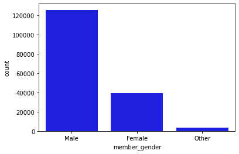

```python
sb.countplot(df_clean.member_gender, color='b');
```

#### Most users are males, the data are biased towards males

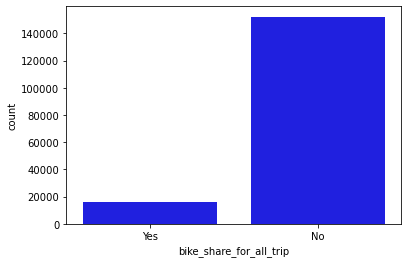

```python
sb.countplot(df_clean.bike_share_for_all_trip, color='b');
```

#### Most of users are not from members enrolled in the Bike Share for All program for low-income residents

> Make sure that, after every plot or related series of plots, that you include a Markdown cell with comments about what you observed, and what you plan on investigating next.

### Discuss the distribution(s) of your variable(s) of interest. Were there any unusual points? Did you need to perform any transformations?

> Its seems that men uses the service more than women .

> Age had some outliers ages like over 64yrs been removed

> Thursday is most busy day as users at highest

### Of the features you investigated, were there any unusual distributions? Did you perform any operations on the data to tidy, adjust, or change the form of the data? If so, why did you do this?

> Age column has outliers / removed

> Duration column outliers removed

> 0 distance rows removed as it might be faulty data